# Automated metadata extraction for the pilot-study assessment

Method, validation and coverage across the pilot-1 and pilot-2 samples

Published

August 19, 2026

```r
# run_pipeline.R sources its modules by relative path, so chunks run from the
# project root rather than from docs/.
knitr::opts_knit$set(root.dir = here::here())

library(readr)
library(dplyr)
library(tidyr)
library(ggplot2)
library(gt)
library(here)
library(scales)

theme_set(theme_minimal(base_size = 12) +
            theme(panel.grid.minor = element_blank(),
                  plot.title.position = "plot"))

PAL <- c("#3B6EA5", "#C1666B", "#7FB069", "#E5A34B", "#8A7090", "#9AA5B1")

read_out <- function(f) read_csv(here(f), show_col_types = FALSE)

pilot_val <- read_out("data/final_extraction_pilot1-and-pilot2.csv")
idx1      <- read_out("data/full_sample_index.csv")
ex1       <- read_out("data/final_extraction_full-empirical-sample.csv")
idx2      <- read_out("data/pilot2_sample_index.csv")
ex2       <- read_out("data/final_extraction_pilot2-sample.csv")

# The 20 extraction columns are identical across the two frames, so the samples
# stack once each row is labelled with the frame it came from. The pilot-1
# driver also extracts the manually coded pilot-2 articles, so those appear in
# both outputs and are deduplicated here; the pilot-1 row is kept.
combined <- bind_rows(
  ex1 |> mutate(frame = "pilot-1 frame"),
  ex2 |> mutate(frame = "pilot-2 frame")
) |>
  distinct(doi, .keep_all = TRUE)

n_frame1 <- nrow(idx1 |> filter(article_status != "pilot2"))
n_frame2 <- nrow(idx2)
n_ex1    <- nrow(ex1)
n_ex2    <- nrow(ex2)
```

## What this is

This meta-scientific assessment asks how psychology articles report **pilot studies**, and whether articles that report one differ from those that do not on transparency and governance markers — journal transparency policy, funding, conflicts of interest and preregistration. Answering that needs those markers for every article in the sampling frame, not only for the articles a human coded.

This report documents the automated pipeline that produces them: what each column means, how accurate it is against manual coding, and what the two samples now contain.

The unit of analysis is the **article**, identified by DOI. Every article contributes at most one row.

## The two samples

The project drew two sampling frames, one for each pilot round. They are independent draws from different search strategies and overlap in a single article, so their extraction outputs stack into one dataset.

```r
tibble(
  Frame = c("Pilot-1 frame", "Pilot-2 frame"),
  `Source file` = c("full_sample.csv", "pilot2_sample.csv"),
  `Articles in frame` = c(n_frame1, n_frame2),
  `Manually coded` = c(
    sum(idx1$article_status == "pilot1"),
    sum(idx2$article_status == "pilot2-coded")),
  `Extraction rows` = c(n_ex1, n_ex2)
) |>
  gt() |>
  tab_header(title = "Sampling frames and extraction coverage") |>
  fmt_integer(columns = where(is.numeric)) |>
  cols_align("left", columns = c(Frame, `Source file`))
```

Table 1: The two sampling frames and what has been extracted from each.

Sampling frames and extraction coverage

| Frame | Source file | Articles in frame | Manually coded | Extraction rows |
| --- | --- | --- | --- | --- |
| Pilot-1 frame | full_sample.csv | 4,076 | 162 | 4,051 |
| Pilot-2 frame | pilot2_sample.csv | 4,635 | 184 | 4,635 |

The two frames are filtered differently, and this matters for any analysis that pools them:

- **Pilot-1 frame** — extraction is restricted to articles an LLM classifier marked as *empirical*, plus every manually coded article regardless of that classification. Articles classified non-empirical are in the index but carry no extraction row.
- **Pilot-2 frame** — extracted **unfiltered**. The classifier has run over the pilot-1 frame only, so no `empirical` column exists for pilot 2.

To pool the frames on comparable terms, filter the pilot-1 rows on `empirical == "yes"` in `data/full_sample_index.csv` and accept that the pilot-2 rows are unrestricted, or run the classifier over the pilot-2 abstracts first.

### Coverage within each frame

```r
cov1 <- idx1 |>
  filter(article_status != "pilot2") |>
  mutate(state = case_when(
    doi %in% ex1$doi                  ~ "extracted",
    is.na(tei_file)                   ~ "no TEI (PDF not converted)",
    TRUE                              ~ "excluded: not classified empirical")) |>
  count(state, name = "Pilot-1 frame")

cov2 <- idx2 |>
  mutate(state = case_when(
    doi %in% ex2$doi ~ "extracted",
    is.na(tei_file)  ~ "no TEI (PDF not converted)",
    TRUE             ~ "TEI present but no extraction row")) |>
  count(state, name = "Pilot-2 frame")

full_join(cov1, cov2, by = "state") |>
  arrange(desc(coalesce(`Pilot-1 frame`, 0L) + coalesce(`Pilot-2 frame`, 0L))) |>
  rename(Status = state) |>
  gt() |>
  tab_header(title = "Article status within each sampling frame") |>
  fmt_integer(columns = where(is.numeric)) |>
  sub_missing(missing_text = "—")
```

Table 2: Why frame articles have no extraction row.

Article status within each sampling frame

| Status | Pilot-1 frame | Pilot-2 frame |
| --- | --- | --- |
| extracted | 3,867 | 4,635 |
| excluded: not classified empirical | 204 | — |
| no TEI (PDF not converted) | 5 | — |

## Method

Each article enters the pipeline as a **DOI** plus a path to a **GROBID TEI** file — a structured XML rendering of the article PDF, with headings, sections and back-matter marked up. TEI gives the extractors document structure, so a funding statement can be located by its heading rather than by scanning prose.

PDF → TEI conversion runs as a GitHub Action in the companion `pilot2_pdf_conversion` repository: the PDFs live in a Google Drive folder, a fleet of parallel runners each convert a share of them through GROBID 0.8.2.1-full, and one job commits the result.

DOI → TEI matching is deterministic. TEI filenames carry the DOI with every `/` flattened to `-`, and a DOI suffix can itself contain `-`, so the slashes cannot be restored by position. Both sides are therefore compared on a key that lower-cases the DOI and rewrites `/` as `-`.

### The four extraction modules

```r
tibble(
  Module = c("1. DOI metadata", "2. TEI funding & COI",
             "3. Preregistration", "4. Funder → country"),
  Source = c("OpenAlex + Crossref APIs", "GROBID TEI",
             "GROBID TEI + OSF API", "Crossref Funder Registry + OpenAlex/ROR"),
  Produces = c(
    "Journal, ISSN, SJR, TOP Factor, first-author affiliation, structured funder IDs, Crossref COI text, abstract",
    "Funding statement and conflict-of-interest statement text, located by document structure",
    "Preregistration present, platform, URL; registered-report and trial-registry flags",
    "Country for every named or ID-matched funder")
) |>
  gt() |>
  tab_header(title = "Pipeline modules") |>
  cols_width(Produces ~ px(420)) |>
  cols_align("left", columns = everything())
```

Table 3: The extraction modules, in run order.

Pipeline modules

| Module | Source | Produces |
| --- | --- | --- |
| 1. DOI metadata | OpenAlex + Crossref APIs | Journal, ISSN, SJR, TOP Factor, first-author affiliation, structured funder IDs, Crossref COI text, abstract |
| 2. TEI funding & COI | GROBID TEI | Funding statement and conflict-of-interest statement text, located by document structure |
| 3. Preregistration | GROBID TEI + OSF API | Preregistration present, platform, URL; registered-report and trial-registry flags |
| 4. Funder → country | Crossref Funder Registry + OpenAlex/ROR | Country for every named or ID-matched funder |

Two design choices are worth stating explicitly.

**Preregistration is gated on the registration template, not on the word.** An OSF link alone does not count: the pipeline resolves the OSF GUID through the OSF API and asks whether the object is a *registration* and, if so, under which template. An OSF *project* link is recorded as such and does not set `prereg_present`. Trial registries (ClinicalTrials.gov and equivalents) and AsPredicted are detected separately, and `registration_any` is the union of preregistration, registered report and trial registry.

**Conflict of interest is classified by negation, not by presence.** A COI statement is first located (TEI, falling back to the Crossref deposit); a case-insensitive negation regex then decides whether it declares *no* conflict. No statement at all is a third, distinct category — the absence of a declaration is a finding, not a missing value.

### Caching

Every networked lookup — OpenAlex and Crossref metadata, OSF GUIDs and registration templates, funder ID and funder name resolution — is cached to disk. A rerun over the same DOIs makes no network calls, and `run_pipeline(..., use_api = FALSE)` errors rather than silently reaching the network, which is what makes the outputs reproducible offline.

### The 20 output columns

```r
tibble::tribble(
  ~Column, ~Meaning,
  "doi", "Article DOI, normalised to lower case (join key)",
  "journal, issn", "Venue name and primary ISSN",
  "top_factor, sjr", "Journal transparency (TOP Factor) and Scimago (SJR) scores",
  "first_author_country", "First author's country, preferring the article-level affiliation over the author's OpenAlex profile",
  "first_author_location_full", "Institution, city, region, country for the same",
  "first_author_location_source", "Which of the two supplied the location",
  "funding_category", "funded / no funding / no statement",
  "funding_statement", "The extracted funding text (audit trail)",
  "funders", "Named funders, ||-separated",
  "funding_country", "Distinct funder countries, ||-separated",
  "coi_statement", "The extracted conflict-of-interest text (audit trail)",
  "coi_category", "conflict declared / no conflict declared / no statement",
  "prereg_present", "Whether the article reports a study preregistration",
  "prereg_platform", "OSF registration, AsPredicted, ClinicalTrials.gov, …",
  "prereg_url", "Registration link(s)",
  "is_registered_report", "Registered Report",
  "is_trial_registry", "Trial or health-registry entry",
  "registration_any", "Any of the three above"
) |>
  gt() |>
  tab_header(title = "Output schema") |>
  cols_width(Column ~ px(220), Meaning ~ px(480)) |>
  cols_align("left", columns = everything())
```

Table 4: The extraction schema. Every row of both outputs has these columns.

Output schema

| Column | Meaning |
| --- | --- |
| doi | Article DOI, normalised to lower case (join key) |
| journal, issn | Venue name and primary ISSN |
| top_factor, sjr | Journal transparency (TOP Factor) and Scimago (SJR) scores |
| first_author_country | First author's country, preferring the article-level affiliation over the author's OpenAlex profile |
| first_author_location_full | Institution, city, region, country for the same |
| first_author_location_source | Which of the two supplied the location |
| funding_category | funded / no funding / no statement |
| funding_statement | The extracted funding text (audit trail) |
| funders | Named funders, \|\|-separated |
| funding_country | Distinct funder countries, \|\|-separated |
| coi_statement | The extracted conflict-of-interest text (audit trail) |
| coi_category | conflict declared / no conflict declared / no statement |
| prereg_present | Whether the article reports a study preregistration |
| prereg_platform | OSF registration, AsPredicted, ClinicalTrials.gov, … |
| prereg_url | Registration link(s) |
| is_registered_report | Registered Report |
| is_trial_registry | Trial or health-registry entry |
| registration_any | Any of the three above |

## Validation against manual coding

Two rounds of manual coding provide the ground truth: 162 articles in pilot 1 and 184 in pilot 2. Three pipeline outputs have a manual counterpart in the coding form — `funding_category`, `coi_category` and `prereg_present`. Agreement is measured only on articles where a coder gave an answer.

```r
source(here("run_pipeline.R"))

m1 <- read.csv(here("data/inputs/2025-12-09_Codingform_PilotingAssessment_pilot.csv"),
               check.names = TRUE, stringsAsFactors = FALSE)
m2 <- read.csv(here("data/inputs/2026-04-03_Codingform_PilotingAssessment_pilot2.csv"),
               check.names = TRUE, stringsAsFactors = FALSE)

man <- bind_rows(
  tibble(doi = norm_doi(m1[["X1.2..Article.DOI"]]), pilot = "pilot 1",
         mfund   = m1[["X8.1..Does.the.article.include.a.funding.statement."]],
         mcoi    = m1[["X8.2..Does.the.article.include.a.statement.indicating.whether.there.were.any.conflicts.of.interest."]],
         mprereg = m1[["X2.2...Does.the.article.state.whether.or.not.reported.study.studies.were.preregistered."]]),
  tibble(doi = norm_doi(m2[["X1.2..Article.DOI"]]), pilot = "pilot 2",
         mfund   = m2[["X8.1..Does.the.article.include.a.funding.statement."]],
         mcoi    = m2[["X8.2..Does.the.article.include.a.statement.indicating.whether.there.were.any.conflicts.of.interest..COI.."]],
         mprereg = m2[["X2.2...According.to.what.is.stated.in.the.article..were.the.reported.study.ies..preregistered.."]])
) |>
  filter(doi != "", doi != "test") |>
  distinct(doi, .keep_all = TRUE) |>
  mutate(
    man_fund   = mapply(manual_funding_category, mfund, ifelse(pilot == "pilot 1", "pilot1", "pilot2")),
    man_coi    = vapply(mcoi, manual_coi_category, character(1)),
    man_prereg = vapply(mprereg, manual_prereg, logical(1)))

val <- pilot_val |> inner_join(man, by = "doi")

acc <- function(d, auto, manual) {
  keep <- !is.na(d[[manual]]) & !is.na(d[[auto]])
  tibble(n = sum(keep), agree = sum(d[[auto]][keep] == d[[manual]][keep])) |>
    mutate(accuracy = agree / n)
}

metrics <- bind_rows(
  lapply(c("pilot 1", "pilot 2"), function(p) {
    d <- val |> filter(pilot == p)
    bind_rows(
      acc(d, "funding_category", "man_fund")   |> mutate(Field = "funding_category"),
      acc(d, "coi_category",     "man_coi")    |> mutate(Field = "coi_category"),
      acc(d, "prereg_present",   "man_prereg") |> mutate(Field = "prereg_present")
    ) |> mutate(Round = p)
  }),
  {
    d <- val
    bind_rows(
      acc(d, "funding_category", "man_fund")   |> mutate(Field = "funding_category"),
      acc(d, "coi_category",     "man_coi")    |> mutate(Field = "coi_category"),
      acc(d, "prereg_present",   "man_prereg") |> mutate(Field = "prereg_present")
    ) |> mutate(Round = "pooled")
  })
```

```r
metrics |>
  mutate(cell = sprintf("%.3f (%d/%d)", accuracy, agree, n)) |>
  select(Field, Round, cell) |>
  pivot_wider(names_from = Round, values_from = cell) |>
  gt() |>
  tab_header(title = "Accuracy against manual coding") |>
  cols_align("left", columns = Field)
```

Table 5: Agreement with manual coding, on articles a coder answered.

Accuracy against manual coding

| Field | pilot 1 | pilot 2 | pooled |
| --- | --- | --- | --- |
| funding_category | 0.904 (47/52) | 0.939 (77/82) | 0.925 (124/134) |
| coi_category | 0.750 (48/64) | 0.855 (71/83) | 0.810 (119/147) |
| prereg_present | 0.938 (60/64) | 0.952 (79/83) | 0.946 (139/147) |

### What a blank funding field means

The pilot-1 coding form asked for the funding statement as **free text**. Coders filled it in when funding existed and left it empty otherwise, so a blank cannot separate *the article has no funding statement* from *the coder did not transcribe one*. Blanks are therefore treated as uncoded and excluded from the funding comparison.

```r
mc <- read_out("data/cache/pipeline_metadata_cache.csv") |>
  mutate(doi = norm_doi(doi)) |>
  select(doi, funding_funder_ids_crossref)

blank1 <- val |>
  filter(pilot == "pilot 1", is.na(mfund) | trimws(mfund) == "") |>
  left_join(mc, by = "doi")

n_blank      <- nrow(blank1)
n_blank_fund <- sum(blank1$funding_category == "funded", na.rm = TRUE)
bf <- blank1 |> filter(funding_category == "funded")
n_blank_tei  <- sum(!is.na(bf$funding_statement) & nzchar(bf$funding_statement))
n_blank_xref <- sum(!is.na(bf$funding_funder_ids_crossref) &
                      nzchar(bf$funding_funder_ids_crossref))
n_blank_none <- sum((is.na(bf$funding_statement) | !nzchar(bf$funding_statement)) &
                      (is.na(bf$funding_funder_ids_crossref) |
                         !nzchar(bf$funding_funder_ids_crossref)))
n_answered1  <- sum(val$pilot == "pilot 1" & !is.na(val$mfund) & trimws(val$mfund) != "")
```

Of the **109** pilot-1 articles with a blank funding field, the pipeline finds funding for **84**. Of those, **78** have a funding statement in the article’s own TEI and **57** carry a publisher-deposited Crossref funder ID — the publisher’s structured record of who paid for the work. Exactly **1** have neither. Only **52** pilot-1 articles carry an answer in the field.

Pilot 2 replaced the free-text box with a categorical question with forced options, so its blanks are genuinely unanswered rows and every answered row counts.

### Where the pipeline and the coders disagree

Table 6: Pooled confusion matrices. Rows are the pipeline, columns the coder.

```r
conf_gt <- function(auto, manual, title) {
  d <- val |> filter(!is.na(.data[[manual]]), !is.na(.data[[auto]]))
  table(pipeline = d[[auto]], coder = d[[manual]]) |>
    as.data.frame.matrix() |>
    tibble::rownames_to_column("Pipeline") |>
    gt() |>
    tab_header(title = title) |>
    tab_spanner(label = "Manual coding", columns = -Pipeline) |>
    cols_align("left", columns = Pipeline)
}
```

**Funding**

```r
conf_gt("funding_category", "man_fund", "funding_category")
```

funding_category

| Pipeline | Manual coding funded | Manual coding no funding | Manual coding no statement |
| --- | --- | --- | --- |
| funded | 98 | 0 | 3 |
| no funding | 2 | 16 | 0 |
| no statement | 4 | 1 | 10 |

**Conflict of interest**

```r
conf_gt("coi_category", "man_coi", "coi_category")
```

coi_category

| Pipeline | Manual coding conflict declared | Manual coding no conflict declared | Manual coding no statement |
| --- | --- | --- | --- |
| conflict declared | 5 | 1 | 2 |
| no conflict declared | 9 | 82 | 4 |
| no statement | 2 | 10 | 32 |

**Preregistration**

```r
conf_gt("prereg_present", "man_prereg", "prereg_present")
```

prereg_present

| Pipeline | Manual coding FALSE | Manual coding TRUE |
| --- | --- | --- |
| FALSE | 103 | 4 |
| TRUE | 4 | 36 |

### A known blind spot in conflict-of-interest capture

`coi_category == "no statement"` should be read with care for some publishers. Across both frames, 62.4% of articles carry a COI statement, but the rate by publisher runs from **13.0% for APA (`10.1037`, n = 1,021)** to **95.9% for MDPI**, with SAGE, Springer and Taylor & Francis all between 88% and 93%. That spread is too wide to be reporting culture alone.

Checking the source confirms it is a parsing limit. In the validation set, detection sensitivity is **92.9% outside APA and Cambridge but 50.0% within** (n = 27). Taking one verified case, 10.1037/xap0000495: the PDF’s author note reads “The authors have no conflicts of interest to disclose”, and the 87,342-character GROBID TEI contains no match for conflict, competing interest, disclose or disclosure at all. APA places disclosures in the page-1 author note, and GROBID does not carry that note into the TEI. In a sample of 400 articles marked `no statement`, only 10.2% contain any COI wording in their TEI — so the absence is genuine for most, but not for the affected publishers.

Funding is not affected in the same way, because Crossref supplies structured funder IDs for 58.6% of APA articles and the pipeline uses them. There is no equivalent deposit for COI: a Crossref COI field exists for 7–9% of articles overall and rescued none.

**Implication.** For APA, Cambridge and `10.1192` — 1,808 articles, 21% of the pooled dataset — `no statement` conflates “the article has none” with “we could not see it”, and treating it as an affirmative absence will produce a spurious publisher effect.

**What is being done.** This is [metacheck issue #325](https://github.com/scienceverse/metacheck/issues/325). The maintainers expect it to be resolved by the forthcoming **bibr** import — bibr is the PDF-to-JSON extraction service replacing GROBID inside metacheck, and its author reports that it “has a section classification module that detects ethics/funding/coi sections very well”. We are seeking access to test that claim against this set, which is a good benchmark for it: 8,711 PDFs, 345 manually coded articles, publisher-level sensitivity measured, and 12 confirmed misses to check. bibr is not yet publicly released — there is no public repository, image or self-hosting documentation — so the test waits on either an API key or the server image. Until then the COI column stands as described, and the affected publishers should be handled explicitly in any analysis.

**ImportantOpen question for the team: does open-access funding count as funding?**

**A decision is needed, and it changes the data.** Many articles carry a line such as “Open Access funding enabled and organized by Projekt DEAL” or “Open access funding provided by Alma Mater Studiorum Università di Bologna”. This is a library consortium or institution paying the article-processing charge, not a body that funded the research.

**The pipeline currently excludes it.** Open-access boilerplate is stripped before a section is judged to be a funding statement, so an article whose only funding-like text is an APC arrangement is recorded as `no statement`.

**Coders have counted it as funding.** Two of the funding disagreements listed below are exactly this, not extraction errors: 10.3758/s13428-022-01974-6, where the coder recorded “Open access funding provided by Alma Mater Studiorum Università di Bologna”, and 10.1111/apps.12466, whose only funding-related text in the whole article is the Projekt DEAL line.

**Why it matters beyond those two.** The convention decides how a whole class of European open-access articles is classified, and it interacts with the funder country column: an APC payer would otherwise be recorded as a funder, and its country as a funding country.

**What we need from you:** confirm the exclusion, or ask for it to be reversed — in which case APC payers become funders and the codebook should say so explicitly, so manual and automated coding agree. Either way the rule should be stated in the codebook rather than left implicit.

### Every disagreement, article by article

The matrices above say how many cells disagree, not who was right. The table below lists **every** disagreeing article so that each one can be adjudicated against the source: what the pipeline said, what the coder said, the coder’s raw answer, and the evidence the pipeline acted on. Follow the DOI to check.

```r
ev_trunc <- function(x, n = 160) {
  x <- gsub("\\s+", " ", x)
  ifelse(is.na(x) | !nzchar(x), "(nothing extracted)",
         ifelse(nchar(x) > n, paste0(substr(x, 1, n), "…"), x))
}

disagree <- bind_rows(
  val |> filter(!is.na(man_fund), funding_category != man_fund) |>
    transmute(Field = "funding_category", doi, Round = pilot,
              Pipeline = funding_category, Coder = man_fund,
              `Coder's raw answer` = ev_trunc(mfund),
              `Pipeline evidence` = ev_trunc(coalesce(funding_statement, funders))),
  val |> filter(!is.na(man_coi), coi_category != man_coi) |>
    transmute(Field = "coi_category", doi, Round = pilot,
              Pipeline = coi_category, Coder = man_coi,
              `Coder's raw answer` = ev_trunc(mcoi),
              `Pipeline evidence` = ev_trunc(coi_statement)),
  val |> filter(!is.na(man_prereg), prereg_present != man_prereg) |>
    transmute(Field = "prereg_present", doi, Round = pilot,
              Pipeline = as.character(prereg_present), Coder = as.character(man_prereg),
              `Coder's raw answer` = ev_trunc(mprereg),
              `Pipeline evidence` = ev_trunc(paste0(
                coalesce(prereg_platform, "no platform"), " — ",
                coalesce(prereg_url, "no URL"),
                ifelse(is_trial_registry, " [trial registry]", ""),
                ifelse(registration_any, " [registration_any = TRUE]", ""))))
) |> arrange(Field, Pipeline, Coder)

dis_tbl <- function(f) {
  disagree |>
    filter(Field == f) |>
    mutate(DOI = sprintf("[%s](https://doi.org/%s)", doi, doi)) |>
    select(DOI, Round, Pipeline, Coder, `Coder's raw answer`, `Pipeline evidence`) |>
    gt() |>
    fmt_markdown(columns = DOI) |>
    tab_header(title = paste(f, "— every disagreeing article"),
               subtitle = sprintf("%d of %d coded articles",
                                  sum(disagree$Field == f),
                                  sum(!is.na(val[[c(funding_category = "man_fund",
                                                    coi_category = "man_coi",
                                                    prereg_present = "man_prereg")[[f]]]])))) |>
    cols_width(DOI ~ px(230), Round ~ px(70), Pipeline ~ px(120), Coder ~ px(120),
               `Coder's raw answer` ~ px(240), `Pipeline evidence` ~ px(360)) |>
    tab_options(table.width = pct(100), table.font.size = px(13)) |>
    tab_style(style = cell_text(size = px(12)),
              locations = cells_body(columns = c(`Coder's raw answer`, `Pipeline evidence`))) |>
    tab_style(style = cell_text(whitespace = "nowrap"),
              locations = cells_body(columns = c(DOI, Round, Pipeline, Coder))) |>
    cols_align("left", columns = everything())
}
```

**Funding (10)**

```r
dis_tbl("funding_category")
```

funding_category — every disagreeing article

10 of 134 coded articles

| DOI | Round | Pipeline | Coder | Coder's raw answer | Pipeline evidence |
| --- | --- | --- | --- | --- | --- |
| 10.1016/j.jecp.2023.105761 | pilot 2 | funded | no statement | No, there is no funding statement. | H2020 Marie Skłodowska-Curie Actions |
| 10.1037/pspi0000433 | pilot 2 | funded | no statement | No, there is no funding statement. | project administration, supervision, validation, and writing-review and editing. Nadav funding acquisition and resources, a supporting role in formal analysis, … |
| 10.1037/xge0001449 | pilot 2 | funded | no statement | No, there is no funding statement. | This work was supported by a Multidisciplinary University Research Initiative (MURI) award from the Office of Naval Research (N00014-16-1-2832) and the National… |
| 10.1007/s10802-022-00919-z | pilot 1 | no funding | funded | No funding was received for conducting this study. | Funding No funding was received for conducting this study. |
| 10.1002/eat.23694 | pilot 1 | no funding | funded | This research received no specific grant from any funding agency, nor from commercial entities or the not-for-profit sector. Open Access funding enabled and org… | ACKNOWLEDGEMENTSWe thank Felicitas Hirler, Julia Maier, and Antonia Sasko for data entry and data management and all the patients for consenting to participate … |
| 10.1037/pag0000703 | pilot 1 | no statement | funded | acknowledge NIH Grant R01 HD-21338, Eunice Kennedy Shriver National Institute of Child Health & Human Development (NICHD) to Nelson Cowan | (nothing extracted) |
| 10.3758/s13428-022-01974-6 | pilot 1 | no statement | funded | Open access funding provided by Alma Mater Studiorum Università di Bologna within the CRUI-CARE Agreement. | (nothing extracted) |
| 10.1080/09658211.2023.2256055 | pilot 2 | no statement | funded | Yes, and the statement provides funding information. | Funding |
| 10.1111/apps.12466 | pilot 2 | no statement | funded | Yes, and the statement provides funding information. | (nothing extracted) |
| 10.1037/emo0001136 | pilot 1 | no statement | no funding | This research did not receive any specific grant from funding agencies in the public, commercial, or not-for-profit sectors. | (nothing extracted) |

**Conflict of interest (28)**

```r
dis_tbl("coi_category")
```

coi_category — every disagreeing article

28 of 147 coded articles

| DOI | Round | Pipeline | Coder | Coder's raw answer | Pipeline evidence |
| --- | --- | --- | --- | --- | --- |
| 10.3390/bs13070596 | pilot 2 | conflict declared | no conflict declared | Yes, the statement says that there is no conflict of interest | World Medical Association Declaration of Helsinki. Ethical principles for medical research involving human subjects |
| 10.1002/ijop.12937 | pilot 2 | conflict declared | no statement | No, there is no conflict of interest statement | United Nations General Assembly. (1948).Universal declaration of human rights(217 [III] A). Paris. |
| 10.1111/cdev.13959 | pilot 2 | conflict declared | no statement | No, there is no conflict of interest statement | On the development of declarative memory \|\| Accounting for change in declarative memory: A cognitive neuroscience perspective |
| 10.1016/j.obhdp.2022.104206 | pilot 1 | no conflict declared | conflict declared | Yes, the statement says that there are one or more conflicts of interest | Declaration of Competing InterestThe authors declare that they have no known competing financial interests or personal relationships that could have appeared to… |
| 10.1080/15374416.2022.2073235 | pilot 1 | no conflict declared | conflict declared | Yes, the statement says that there are one or more conflicts of interest | Disclosure StatementNo potential conflict of interest was reported by the author(s). |
| 10.1177/09567976221093575 | pilot 1 | no conflict declared | conflict declared | Yes, the statement says that there are one or more conflicts of interest | Declaration of Conflicting InterestsThe author(s) declared that there were no conflicts of interest with respect to the authorship or the publication of this ar… |
| 10.1016/j.cognition.2022.105224 | pilot 1 | no conflict declared | conflict declared | Yes, the statement says that there are one or more conflicts of interest | Declaration of Competing InterestThe authors declare no competing interests. |
| 10.1002/job.2675 | pilot 1 | no conflict declared | conflict declared | Yes, the statement says that there are one or more conflicts of interest | CONFLICTS OF INTERESTNo conflicts of interest. |
| 10.1080/0092623x.2023.2226130 | pilot 2 | no conflict declared | conflict declared | Yes, the statement says that there are one or more conflicts of interest | Disclosure statementThe authors have no conflicts of interest to declare that are relevant to the content of this article. |
| 10.1111/jopy.12890 | pilot 2 | no conflict declared | conflict declared | Yes, the statement says that there are one or more conflicts of interest | CONFLICT OF INTEREST STATEMENTAndreas Mokros is first author of the German version of the Hare Psychopathy Checklist-Revised (PCL-R) and receives royalties from… |
| 10.1192/bjo.2023.550 | pilot 2 | no conflict declared | conflict declared | Yes, the statement says that there are one or more conflicts of interest | Declaration of interestNone. |
| 10.1002/acp.4095 | pilot 2 | no conflict declared | conflict declared | Yes, the statement says that there are one or more conflicts of interest | CONFLICT OF INTEREST STATEMENTThe authors have no financial or personal relationships with other people or organizations that could inappropriately influence/bi… |
| 10.1002/eat.23864 | pilot 1 | no conflict declared | no statement | No, there is no conflict of interest statement | CONFLICT OF INTERESTThe authors have no conflicts of interest to disclose. |
| 10.1016/j.cognition.2022.105113 | pilot 1 | no conflict declared | no statement | No, there is no conflict of interest statement | Declaration of Competing InterestNone. |
| 10.1016/j.cognition.2022.105076 | pilot 1 | no conflict declared | no statement | No, there is no conflict of interest statement | Declaration of Competing InterestThe authors report no conflicts of interest. |
| 10.1080/10447318.2023.2271240 | pilot 2 | no conflict declared | no statement | No, there is no conflict of interest statement | Disclosure statementThe authors declare that they have no known competing financial interests or personal relationships that could have appeared to influence th… |
| 10.1016/j.brat.2022.104152 | pilot 1 | no statement | conflict declared | Yes, the statement says that there are one or more conflicts of interest | (nothing extracted) |
| 10.1002/eat.23867 | pilot 1 | no statement | conflict declared | Yes, the statement says that there are one or more conflicts of interest | (nothing extracted) |
| 10.1016/j.obhdp.2022.104181 | pilot 1 | no statement | no conflict declared | Yes, the statement says that there is no conflict of interest | (nothing extracted) |
| 10.1016/j.cognition.2022.105345 | pilot 1 | no statement | no conflict declared | Yes, the statement says that there is no conflict of interest | (nothing extracted) |
| 10.1016/j.jenvp.2022.101804 | pilot 1 | no statement | no conflict declared | Yes, the statement says that there is no conflict of interest | (nothing extracted) |
| 10.1037/adb0000847 | pilot 1 | no statement | no conflict declared | Yes, the statement says that there is no conflict of interest | (nothing extracted) |
| 10.1037/xge0001147 | pilot 1 | no statement | no conflict declared | Yes, the statement says that there is no conflict of interest | (nothing extracted) |
| 10.1111/jcpp.13672 | pilot 1 | no statement | no conflict declared | Yes, the statement says that there is no conflict of interest | (nothing extracted) |
| 10.1037/xge0001439 | pilot 2 | no statement | no conflict declared | Yes, the statement says that there is no conflict of interest | (nothing extracted) |
| 10.1037/pspi0000433 | pilot 2 | no statement | no conflict declared | Yes, the statement says that there is no conflict of interest | (nothing extracted) |
| 10.1162/opmi_a_00088 | pilot 2 | no statement | no conflict declared | Yes, the statement says that there is no conflict of interest | (nothing extracted) |
| 10.1037/xap0000495 | pilot 2 | no statement | no conflict declared | Yes, the statement says that there is no conflict of interest | (nothing extracted) |

**Preregistration (8)**

```r
dis_tbl("prereg_present")
```

prereg_present — every disagreeing article

8 of 147 coded articles

| DOI | Round | Pipeline | Coder | Coder's raw answer | Pipeline evidence |
| --- | --- | --- | --- | --- | --- |
| 10.1002/eat.23864 | pilot 1 | FALSE | TRUE | Yes, the article states that there is a preregistration | ClinicalTrials.gov — NCT05473013 [trial registry] [registration_any = TRUE] |
| 10.1111/cdev.13845 | pilot 1 | FALSE | TRUE | Yes, the article states that there is a preregistration | OSF project — https://osf.io/r8ct6/?view_only=4d2562cff49243b78f0b5fff84c309d2 \|\| https://osf.io/r8ct6/ |
| 10.1111/desc.13244 | pilot 1 | FALSE | TRUE | Yes, the article states that there is a preregistration | OSF project — https://osf.io/hcmv7/ [registration_any = TRUE] |
| 10.1177/21677026231164958 | pilot 2 | FALSE | TRUE | Yes, the article states that there is a preregistration | ClinicalTrials.gov — https://osf.io/skmwj/?view_only=e696843a51a7434bb3733335b28d9f7a \|\| https://osf.io/skmwj/?view_only \|\| NCT04380259 [trial registry] [regist… |
| 10.3758/s13428-022-01804-9 | pilot 1 | TRUE | FALSE | There is a statement that there was NO preregistration. | statement (no URL) — https://osf.io/8cd67/?view_only=bbf36bb49eb04b83a30a6aea98ab0f78 [registration_any = TRUE] |
| 10.1111/jopy.12855 | pilot 2 | TRUE | FALSE | No, the article states that there is no preregistration | OSF registration — https://osf.io/qxkjw/?view_only=aef02f2fed5145c68d7c21ed2a2d4e50 \|\| https://osf.io/qxkjw/ \|\| OSF.IO/J4NP2 [registration_any = TRUE] |
| 10.1080/13506285.2023.2192993 | pilot 2 | TRUE | FALSE | No, the article states that there is no preregistration | AsPredicted \|\| OSF project — https://aspredicted.org/4c7f7.pdf \|\| https://aspredicted.org/f7fz5.pdf \|\| https://aspredicted.org/j46ga.pdf \|\| https://aspredicted.… |
| 10.1038/s41562-023-01731-5 | pilot 2 | TRUE | FALSE | This is a RR | OSF project — https://osf.io/vaq2g/ \|\| osf.io/pf8am \|\| osf.io/vaq2g [registration_any = TRUE] |

```r
csv <- paste(capture.output(write.csv(disagree, row.names = FALSE)), collapse = "\n")
cat(sprintf(
  '<p><a download="pipeline_coder_disagreements.csv" href="data:text/csv;base64,%s">Download all %d disagreements as CSV</a> — for adjudicating offline and recording a verdict per row.</p>',
  base64enc::base64encode(charToRaw(csv)), nrow(disagree)))
```

Download all 46 disagreements as CSV — for adjudicating offline and recording a verdict per row.

**One pattern to check first.** Several preregistration disagreements look definitional rather than factual: the pipeline separates a *preregistration* from a *trial-registry* entry, so an article registered on ClinicalTrials.gov gets `prereg_present = FALSE` but `registration_any = TRUE`, while a coder asked “were the studies preregistered?” may reasonably answer yes. Where the evidence column shows `[trial registry]`, the two are answering different questions, and `registration_any` is the column that matches the coder’s intent.

## Results

All figures below come from the two extraction outputs as they stand: 4,051 articles from the pilot-1 frame and 4,635 from the pilot-2 frame. Read differences *between* frames with care — the pilot-1 rows are restricted to articles classified empirical, the pilot-2 rows are not, and the two frames were drawn by different search strategies. The comparison the study is designed to make is *within* the pilot-2 frame, between keyword hits and non-hits.

```r
share <- function(d, col) {
  d |> count(frame, value = .data[[col]]) |>
    group_by(frame) |> mutate(pct = n / sum(n)) |> ungroup()
}

fund_share   <- share(combined, "funding_category")
coi_share    <- share(combined, "coi_category")
reg_share    <- combined |>
  count(frame, value = registration_any) |>
  group_by(frame) |> mutate(pct = n / sum(n)) |> ungroup() |>
  mutate(value = ifelse(value, "registered", "not registered"))

pct <- function(d, v, f) {
  x <- d |> filter(frame == f, value == v)
  if (nrow(x) == 0) return("0%")
  sprintf("%.0f%%", 100 * x$pct)
}
```

### Funding, conflicts of interest and registration

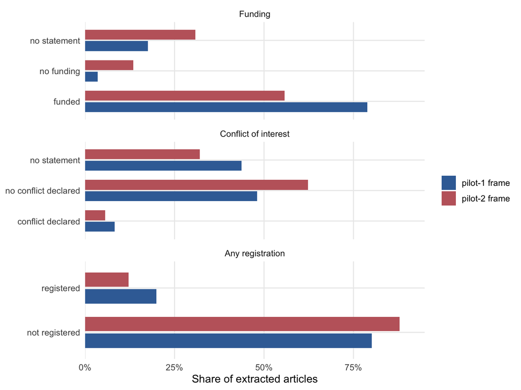

Figure 1: Distribution of the three headline categories across the two frames.

```r
bind_rows(
  fund_share |> mutate(field = "Funding"),
  coi_share  |> mutate(field = "Conflict of interest"),
  reg_share  |> mutate(field = "Any registration")
) |>
  mutate(field = factor(field, c("Funding", "Conflict of interest", "Any registration"))) |>
  ggplot(aes(pct, value, fill = frame)) +
  geom_col(position = position_dodge(width = 0.75), width = 0.65) +
  facet_wrap(~field, ncol = 1, scales = "free_y") +
  scale_x_continuous(labels = percent_format(accuracy = 1),
                     expand = expansion(mult = c(0, 0.08))) +
  scale_fill_manual(values = PAL[1:2]) +
  labs(x = "Share of extracted articles", y = NULL, fill = NULL)
```

```r
bind_rows(
  fund_share |> mutate(Field = "funding_category"),
  coi_share  |> mutate(Field = "coi_category"),
  reg_share  |> mutate(Field = "registration_any")
) |>
  mutate(cell = sprintf("%s (%.0f%%)", comma(n), 100 * pct)) |>
  select(Field, Category = value, frame, cell) |>
  pivot_wider(names_from = frame, values_from = cell) |>
  gt(groupname_col = "Field") |>
  tab_header(title = "Funding, COI and registration by frame") |>
  sub_missing(missing_text = "—") |>
  cols_align("left", columns = Category)
```

Table 7: Headline shares by frame.

Funding, COI and registration by frame

| Category | pilot-1 frame | pilot-2 frame |
| --- | --- | --- |
| funding_category |  |  |
| funded | 3,197 (79%) | 2,482 (56%) |
| no funding | 143 (4%) | 598 (13%) |
| no statement | 711 (18%) | 1,370 (31%) |
| coi_category |  |  |
| conflict declared | 333 (8%) | 249 (6%) |
| no conflict declared | 1,946 (48%) | 2,773 (62%) |
| no statement | 1,772 (44%) | 1,428 (32%) |
| registration_any |  |  |
| not registered | 3,246 (80%) | 3,910 (88%) |
| registered | 805 (20%) | 540 (12%) |

Three things stand out.

**Funding statements are far more common in the pilot-1 frame** — 79% of its articles are recorded as funded against 56% in the pilot-2 frame — and the gap runs the other way for articles with no funding statement at all. The frames’ journal mixes differ enough to explain this without any pipeline difference: the TOP Factor is missing for 1,717 pilot-2 articles against 257 in pilot 1, meaning the pilot-2 frame reaches further outside the set of journals with a recorded transparency policy.

**Conflict-of-interest reporting goes the other way.** A COI statement of some kind is present for 68.2% of pilot-2 articles against 56.3% of pilot-1 articles. Declared conflicts remain rare in both (8% and 6%); the common case by far is an explicit statement that there is no conflict.

**Registration is a minority practice in both frames** — 20% and 12% of articles report any registration at all.

### Preregistration platforms

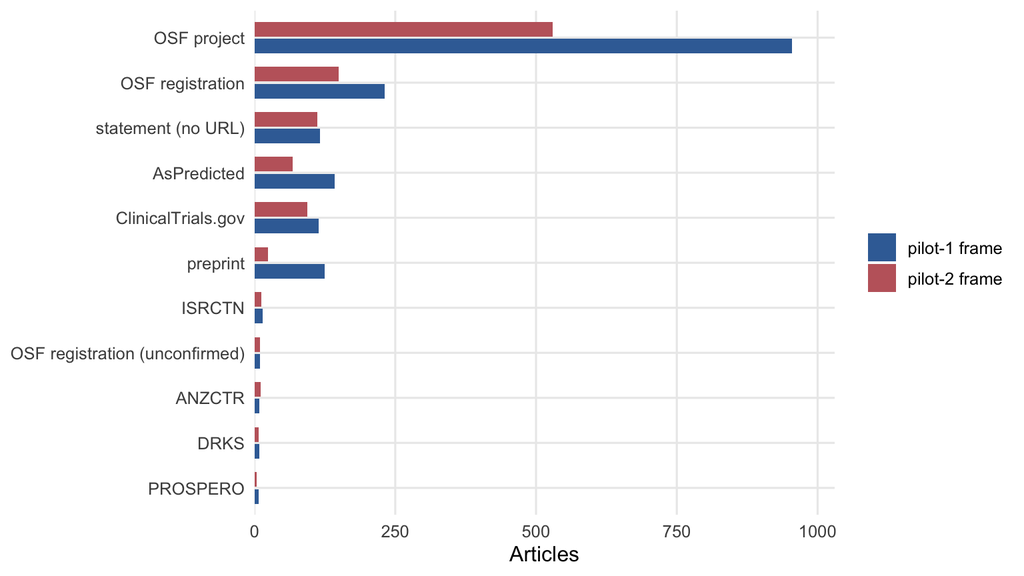

Figure 2: Where articles that report a registration register it.

```r
combined |>
  filter(!is.na(prereg_platform)) |>
  tidyr::separate_rows(prereg_platform, sep = "\\|\\|") |>
  mutate(prereg_platform = trimws(prereg_platform)) |>
  count(frame, prereg_platform) |>
  group_by(prereg_platform) |> filter(sum(n) >= 5) |> ungroup() |>
  mutate(prereg_platform = reorder(prereg_platform, n, sum)) |>
  ggplot(aes(n, prereg_platform, fill = frame)) +
  geom_col(position = position_dodge(width = 0.75), width = 0.65) +
  scale_fill_manual(values = PAL[1:2]) +
  scale_x_continuous(expand = expansion(mult = c(0, 0.08))) +
  labs(x = "Articles", y = NULL, fill = NULL)
```

### Journal transparency and first-author geography

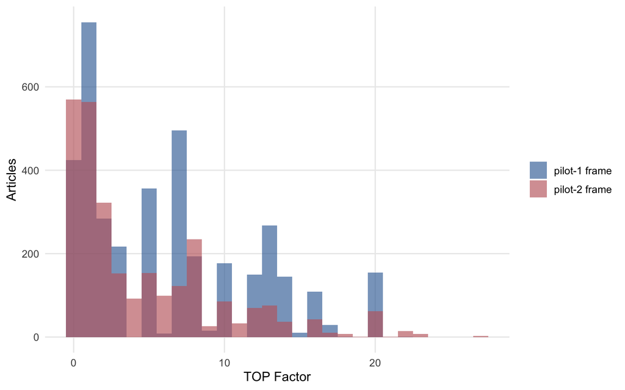

Figure 3: TOP Factor distribution and the ten most common first-author countries.

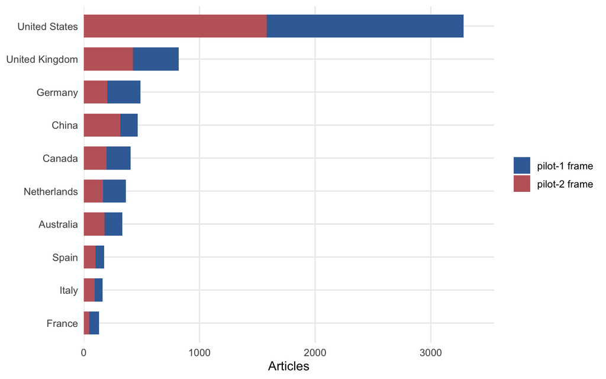

Figure 4: TOP Factor distribution and the ten most common first-author countries.

```r
p_top <- combined |>
  filter(!is.na(top_factor)) |>
  ggplot(aes(top_factor, fill = frame)) +
  geom_histogram(binwidth = 1, position = "identity", alpha = 0.65) +
  scale_fill_manual(values = PAL[1:2]) +
  labs(x = "TOP Factor", y = "Articles", fill = NULL)

p_geo <- combined |>
  filter(!is.na(first_author_country)) |>
  count(frame, first_author_country) |>
  group_by(first_author_country) |> mutate(tot = sum(n)) |> ungroup() |>
  slice_max(tot, n = 20, with_ties = FALSE) |>
  mutate(first_author_country = reorder(first_author_country, tot)) |>
  ggplot(aes(n, first_author_country, fill = frame)) +
  geom_col(width = 0.7) +
  scale_fill_manual(values = PAL[1:2]) +
  scale_x_continuous(expand = expansion(mult = c(0, 0.08))) +
  labs(x = "Articles", y = NULL, fill = NULL)

p_top
p_geo
```

### Pilot-keyword screening

The pilot-2 index records whether the pilot-keyword screen (`pilot`, `preliminary study`, `feasibility study`) matched anywhere outside the reference list. This is the contrast the study is built around, and it only became available once the whole frame was converted: the PDFs converted first were themselves a keyword-selected subset, so the non-hit group did not exist as machine-readable text until now.

A keyword hit is a **screen, not a coding decision** — an article that mentions a pilot study someone else ran counts as a hit. Treat the contrast below as an upper bound on how cleanly the groups separate.

```r
kw <- ex2 |>
  left_join(idx2 |> select(doi, keyword_hit), by = "doi") |>
  filter(!is.na(keyword_hit))

kw_test <- function(flag, label) {
  d <- kw |> mutate(y = flag)
  t <- table(d$keyword_hit, d$y)
  p <- prop.test(t[, "TRUE"], rowSums(t))
  tibble(
    Marker    = label,
    `No hit`  = p$estimate[[1]],
    `Hit`     = p$estimate[[2]],
    `Difference (pp)` = 100 * (p$estimate[[2]] - p$estimate[[1]]),
    `95% CI`  = sprintf("%.1f to %.1f", -100 * p$conf.int[2], -100 * p$conf.int[1]),
    p.value   = p$p.value)
}

kw_tbl <- bind_rows(
  kw_test(kw$funding_category == "funded",  "Funded"),
  kw_test(kw$coi_category != "no statement", "COI statement present"),
  kw_test(kw$prereg_present,                "Preregistration reported"),
  kw_test(kw$registration_any,              "Any registration"))
```

```r
kw_tbl |>
  gt() |>
  tab_header(
    title = "Pilot-keyword hits vs non-hits",
    subtitle = sprintf("%s hits, %s non-hits",
                       comma(sum(kw$keyword_hit)), comma(sum(!kw$keyword_hit)))) |>
  fmt_percent(columns = c(`No hit`, Hit), decimals = 1) |>
  fmt_number(columns = `Difference (pp)`, decimals = 1) |>
  fmt_scientific(columns = p.value, decimals = 1) |>
  cols_align("left", columns = Marker)
```

Table 8: Transparency markers by pilot-keyword screen, pilot-2 frame.

Pilot-keyword hits vs non-hits

718 hits, 3,917 non-hits

| Marker | No hit | Hit | Difference (pp) | 95% CI | p.value |
| --- | --- | --- | --- | --- | --- |
| Funded | 54.6% | 63.6% | 9.0 | 5.1 to 12.9 | 9.3 × 10<sup>−6</sup> |
| COI statement present | 67.7% | 70.8% | 3.1 | -0.6 to 6.8 | 1.1 × 10<sup>−1</sup> |
| Preregistration reported | 9.4% | 16.7% | 7.3 | 4.4 to 10.3 | 5.4 × 10<sup>−9</sup> |
| Any registration | 11.0% | 21.0% | 10.1 | 6.9 to 13.3 | 9.9 × 10<sup>−14</sup> |

Articles the screen flags are markedly more likely to report a registration. Any registration rises from 11.0% among non-hits to 21.0% among hits — a difference of 10.1 pp (95% CI 6.9 to 13.3) — and preregistration specifically from 9.4% to 16.7%, 7.3 pp (95% CI 4.4 to 10.3). Funding follows the same direction more weakly, 9.0 pp (95% CI 5.1 to 12.9).

Conflict-of-interest reporting does not separate the groups: the difference is 3.1 pp (95% CI -0.6 to 6.8), an interval that includes zero.

Whether this reflects something about pilot studies or about the kind of research that mentions them is not something the screen can settle — it is a description of the frame, not a causal claim, and the manual coding is what will distinguish articles that *report* a pilot study from those that merely mention one.

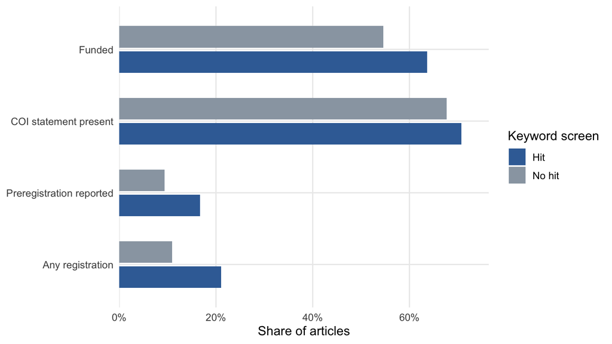

Figure 5: Transparency markers among pilot-keyword hits and non-hits.

```r
kw_tbl |>
  select(Marker, `No hit`, Hit) |>
  pivot_longer(-Marker, names_to = "group", values_to = "p") |>
  mutate(Marker = factor(Marker, rev(kw_tbl$Marker))) |>
  ggplot(aes(p, Marker, fill = group)) +
  geom_col(position = position_dodge(width = 0.7), width = 0.6) +
  scale_x_continuous(labels = percent_format(accuracy = 1),
                     expand = expansion(mult = c(0, 0.08))) +
  scale_fill_manual(values = c(`No hit` = PAL[6], Hit = PAL[1])) +
  labs(x = "Share of articles", y = NULL, fill = "Keyword screen")
```

## Reproducing this

```
# pilot-1 frame
Rscript run_full_sample.R

# pilot-2 frame
Rscript run_pilot2_sample.R

# validation against the manual coding
PIPELINE_RUN=1 Rscript run_pipeline.R
```

All three read from the on-disk caches under `data/cache/`, so a rerun makes no network calls. Column-by-column derivation rules are in `docs/README_pipeline.md`.